# RV144 Aids trials

instr

April 13, 2016

# Thailand Aids study

## Introduction

In the late 1980s in Thailand, there was a dramatic increase in the prevalence of infection with the human immunodeficiency virus type 1 (HIV-1) in sentinel surveillance cohorts.1-3 Initially, these groups consisted of injection-drug users and commercial sex workers; they were subsequently expanded to include persons in the general population. By 1995, the overall seroprevalence of HIV-1 reached a peak of 3.7% among conscripts in the Royal Thai Army and of 12.5% among conscripts from Northern Thailand.2,4,5 The Thai Ministry of Public Health responded with an effective HIV-prevention campaign, and the number of new HIV-1 infections per year decreased from an estimated 143,000 in 1990 to 14,000 in 2007.2,4,6-9 The persistence of new infection despite these measures led public health officials to conclude that an HIV vaccine, within the context of a broader HIV-prevention program, was needed for better control of the epidemic.

## Methods and data

Study Design and Population This study was a community-based, randomized, multicenter, double-blind, placebo-controlled efficacy trial of the prime–boost combination of vaccines containing ALVAC-HIV (vCP1521) (Sanofi Pasteur) and AIDSVAX B/E (Global Solutions for Infectious Diseases). For details regarding the vaccines and placebo, see the Supplementary Appendix, available with the full text of this article at NEJM.org. The study was designed to evaluate two coprimary end points: the prevention of HIV-1 infection and the effect of vaccination on the early viral load after infection. The trial was conducted through facilities of the Thai Ministry of Public Health in Rayong and Chon Buri provinces. From September 2003 through December 2005, a total of 16,402 volunteers were enrolled. Thai men and women who were between the ages of 18 and 30 years and who were not infected with HIV were recruited from the community without regard to HIV risk (i.e., community risk). Written informed consent was obtained from all volunteers, who were required to pass a written test of understanding. Women were counseled to practice effective contraception until 3 months after the last vaccination; pregnant and breast-feeding women were excluded.

### Study Design and Population

This study was a community-based, randomized, multicenter, double-blind, placebo-controlled efficacy trial of the prime–boost combination of vaccines containing ALVAC-HIV (vCP1521) (Sanofi Pasteur) and AIDSVAX B/E (Global Solutions for Infectious Diseases). For details regarding the vaccines and placebo, see the Supplementary Appendix, available with the full text of this article at NEJM.org. The study was designed to evaluate two coprimary end points: the prevention of HIV-1 infection and the effect of vaccination on the early viral load after infection. The trial was conducted through facilities of the Thai Ministry of Public Health in Rayong and Chon Buri provinces. From September 2003 through December 2005, a total of 16,402 volunteers were enrolled. Thai men and women who were between the ages of 18 and 30 years and who were not infected with HIV were recruited from the community without regard to HIV risk (i.e., community risk). Written informed consent was obtained from all volunteers, who were required to pass a written test of understanding. Women were counseled to practice effective contraception until 3 months after the last vaccination; pregnant and breast-feeding women were excluded.

### Primary End Points

HIV-1 Infection HIV-1 infection was diagnosed in 132 subjects (56 in the vaccine group and 76 in the placebo group) during 52,985 person-years of follow-up in the intention-to-treat analysis, in 86 subjects (36 in the vaccine group and 50 in the placebo group) during 36,720 person-years of follow-up in the per-protocol analysis, and in 125 subjects (51 in the vaccine group and 74 in the placebo group) during 52,985 person-years of follow-up in the modified intention-to-treat analysis. One subject in the placebo group who was identified by hospital record as being seropositive for HIV after dying from Pneumocystis jirovecii pneumonia was included in the analysis before the unblinding of the study. This diagnosis of HIV-1 infection was the only one that occurred outside planned procedures. We create the following data set

```r
groupsize = 16402
subgp = groupsize/2
vacine = c(subgp-51,51)
placebo =  c(subgp-74,74)
results = as.table(cbind(vacine,placebo))
rownames(results) <- c("none","aids")
```

## Results

### Graphical results

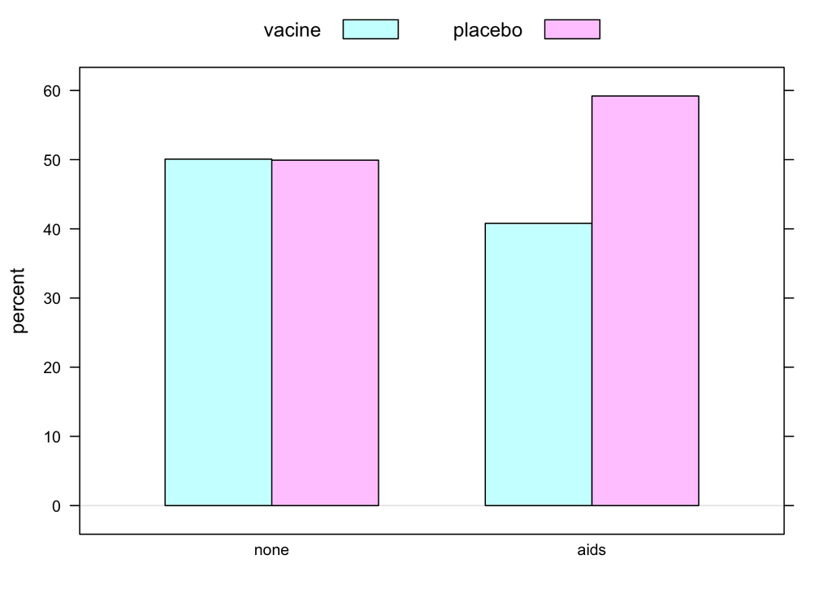

```r
barchartGC(results,type = "percent")
```

### Numerical Results

```r
colPerc(results)
```

```
##       vacine placebo
## none   99.38    99.1
## aids    0.62     0.9
## Total 100.00   100.0
```

```r
rowPerc(results)
```

```
##      vacine placebo  Total
## none  50.07   49.93 100.00
## aids  40.80   59.20 100.00
```

## Inferential results

```
## Pearson's Chi-squared test with Yates' continuity correction
##
## Observed Counts:
##      vacine placebo
## none   8150    8127
## aids     51      74
##
## Counts Expected by Null:
##      vacine placebo
## none 8138.5  8138.5
## aids   62.5    62.5
##
## Contributions to the chi-square statistic:
##      vacine placebo
## none   0.02    0.02
## aids   2.12    2.12
##
##
## Chi-Square Statistic = 3.9017
## Degrees of Freedom of the table = 1
## P-Value = 0.0482
```

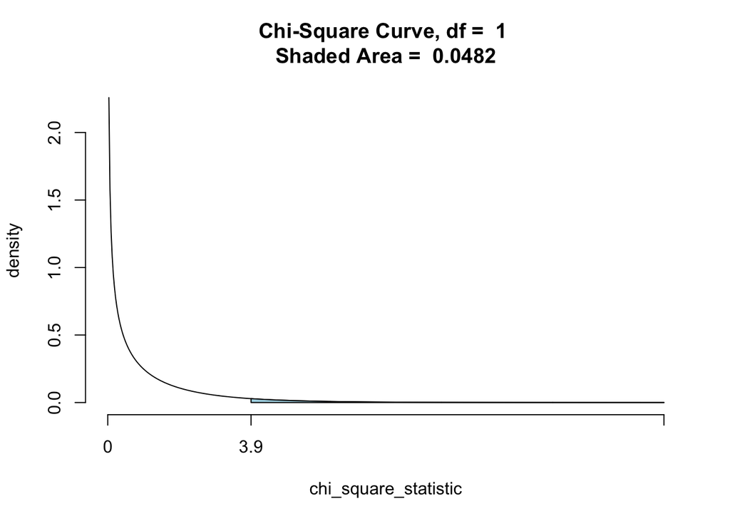

```r
chisqtestGC(results, graph = TRUE)
```

We now test the independence of the aids vaccine and placebo groups.  
$H_0:$ The placebo and aids vaccines treatment is independent of contracting the disease Aids.  
$H_a:$ Having the vaccine is related to contracting the disease.